# Intro to R Day 3

```r
knitr::opts_chunk$set(echo = TRUE)
library(tidyverse)
library(gtsummary)
library(sjPlot)
library(interactions)
library(cardx)
library(mice)
library(nlme)
library(randomNames)
```

## Data Wrangling

```r
data <- read_csv("data1.csv")
cols <- c("id", "sex", "ethgrp", "cvd", "stroke", "smoking", "Cancer")
data <- data %>% mutate_at(cols, factor)
str(data)
```

```
## tibble [200 × 11] (S3: tbl_df/tbl/data.frame)
##  $ id     : Factor w/ 200 levels "1","2","3","4",..: 1 2 3 4 5 6 7 8 9 10 ...
##  $ sex    : Factor w/ 2 levels "0","1": 2 2 1 2 1 2 1 2 1 2 ...
##  $ ethgrp : Factor w/ 3 levels "1","2","3": 3 3 2 2 2 2 2 2 3 1 ...
##  $ weight : num [1:200] 34 39 63 44 47 47 57 39 48 47 ...
##  $ age    : num [1:200] 39 42 63 39 45 40 47 44 44 53 ...
##  $ cvd    : Factor w/ 2 levels "0","1": 1 1 2 1 2 1 2 1 2 1 ...
##  $ stroke : Factor w/ 2 levels "0","1": 1 2 2 2 2 2 2 1 2 2 ...
##  $ smoking: Factor w/ 2 levels "0","1": 1 1 1 2 1 2 1 1 1 1 ...
##  $ Cancer : Factor w/ 2 levels "0","1": 2 2 1 1 1 2 2 1 1 1 ...
##  $ ldl1   : num [1:200] 107 110 111 107 107 108 108 109 110 108 ...
##  $ ldl2   : num [1:200] 106 109 109 108 106 106 109 109 107 110 ...
```

### Joining datasets

#### Stacking 2 datasets on top of each other

If we want to stack two datasets we need to use the `bind` set of functions. We can either use `bind_rows` or `bind_cols` from the `tidyverse` set of packages to do this. Let’s say we have two datasets with the same information but different participants. We want to stack them so we can do some bigger analysis.

```r
data1 <- read_csv("data1.csv")
data2 <- read_csv("data2.csv")
```

Data1 and Data2 have the some number and information in the columns but they are not together. We can join them using `bind_rows`.

```r
data_1_2 <- bind_rows(data1, data2)
```

We can also do more advanced things like select and bind all of the files in a folder with a specific filename or file extension.

```r
paths <- list.files(pattern = "data.*\\.csv", full.names = TRUE)
paths
```

```
## [1] "./data1.csv" "./data2.csv" "./data3.csv" "./data4.csv"
```

```r
files <- map(paths, read_csv)
length(files)
```

```
## [1] 4
```

```r
data_all <- list_rbind(files)
#write_csv(data_all, "data_all.csv")
```

2. Join by ID

If you have 2 datasets with different data that you want to join you can use different join methods. These terms are from computer science. `full_join`, `left_join`, `right_join`, etc.

```r
names_data <- read_csv("names.csv")
glimpse(names_data)
```

```
## Rows: 800
## Columns: 2
## $ id     <dbl> 1, 2, 3, 4, 5, 6, 7, 8, 9, 10, 11, 12, 13, 14, 15, 16, 17, 18, …
## $ parent <chr> "Cesar", "Brandon", "Molly", "Mathew", "Gabrielle", "Chloe", "H…
```

```r
data_all <- left_join(data_all, names_data, by = join_by(id))
table(data_all$parent)
```

[output not shown]

[output cut: 200 more lines]

```
##              1              1              2              1              1
##         Tyesha          Tyler          Tyree          Tyrel          Tyrin
##              1              5              1              2              1
##         Ubaida        Ulysses         Umaira         Usaama         Vanesa
##              1              1              1              1              1
##        Vanessa         Vianey       Victoria          Vilok        Vincent
##              5              1              1              1              1
##         Waatiq        Waheeda        Waseema          Wendy         Wesley
##              1              1              1              1              2
##         Weston           Will        William         Willow          Xavia
##              1              1              1              1              1
##         Xavier         Yadira        Yienkha          Yosan        Zachary
##              1              2              1              1              3
##        Zakkary        Zayyaan            Zoe          Zuhra
##              1              2              1              1
```

## Data Viz

### 1. ggplot2 General

ggplot2 is an open-source data visualization package for the statistical programming language R. Created by Hadley Wickham in 2005, ggplot2 is an implementation of Leland Wilkinson’s Grammar of Graphics—a general scheme for data visualization which breaks up graphs into semantic components such as scales and layers.[Wikipedia](https://en.wikipedia.org/wiki/Ggplot2) The basic idea is to build plots layer by layer. With ggplot2 you can control absolutely everything about a plot.

Data viz is a big place where R and Stata diverge a lot. With R giving much more flexibility (and sometimes annoyance) in terms of visualizing data. We are going to cover basics but recommend the BBC Code Book https://bbc.github.io/rcookbook/ and Keiran Healey’s book *Data Visualization* https://kieranhealy.org/publications/dataviz/ which is part of the the `socviz` package [https://kjhealy.github.io/socviz/](https://kjhealy.github.io/socviz/.)

ggplot2 is built on things called *geoms* which represent different types of plots. There are *geoms* for histograms, scatterplots, beeswarm, and many other plots. Here we are focusing two basic plots and the defaults of everything else.

#### Single bar graphs

People get stuck in R making bar graphs because they are used to Excel and only have the mean value of a given column then making the bar graph from that mean column. It’s always questionnable whether you should be making a bar graph, but if you really need to here is how you can do it in R.

```r
# Recoding income here so we can see the levels more easily

data_all <- data_all %>%
    mutate(stroke_recode = case_when(
        stroke == "1" ~ "Yes",
    stroke == "0" ~ "No"
    ))

data_all$stroke_recode <- as_factor(data_all$stroke_recode)

table(data_all$stroke, data_all$stroke_recode)
```

```
##
##      No Yes
##   0 255   0
##   1   0 545
```

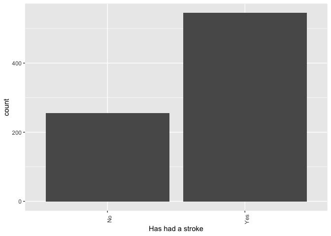

```r
bar_stroke <- ggplot(data_all, aes(stroke_recode)) +
                geom_bar() +
                labs(x = "Has had a stroke") +
                theme(axis.text.x = element_text(angle = 90))
plot(bar_stroke)
```

#### Single variable boxplots

[figure not shown]

```r
boxplot <- ggplot(data_all, aes(stroke_recode)) +
              geom_boxplot() +
              coord_flip()  # Here we add coord_flip function to make the boxplot more as we would expect
plot(boxplot)
```

#### Two variable boxplots

Very useful for showing mean differences and presenting stuff with ANOVA type analysis.

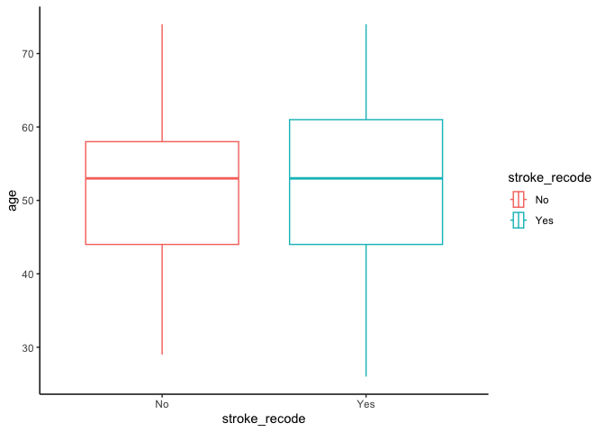

```r
boxplot_stroke <- ggplot(data_all, aes(x = age, y = stroke_recode, colour = stroke_recode)) +
              geom_boxplot() +
              coord_flip() + # Here we add coord_flip function to make the boxplot more as we would expect
              theme_classic()
plot(boxplot_stroke)
```

### 3. Scatter plots

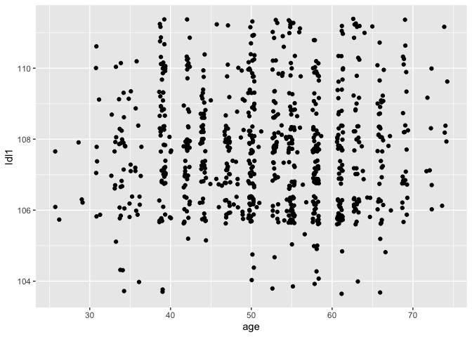

```r
scatter_plot <- ggplot(data_all, aes(x = age, y = ldl1)) +
                  geom_point(position=position_jitter())
plot(scatter_plot)
```

Common things you will see with a scatter plot including the following

#### Adding a regression line

Here we add another *geom* on top of the *geom_point* to start building our plot. We will use *geom_smooth* to add a line. The default in R is a lowess smoother. You can also add a linear regression line. I’m also changing the colour so we can see the difference between the two lines. It’s best to use hexcodes for colours but we can also just use words.

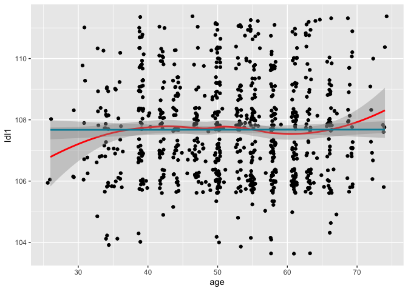

```r
scatter_plot_line <- ggplot(data_all, aes(x = age, y = ldl1)) +
                  geom_point(position = position_jitter()) +
                  geom_smooth(colour = "red") +
                  geom_smooth(method = "lm", colour = "#088da5")
plot(scatter_plot_line)
```

#### Changing the variable names

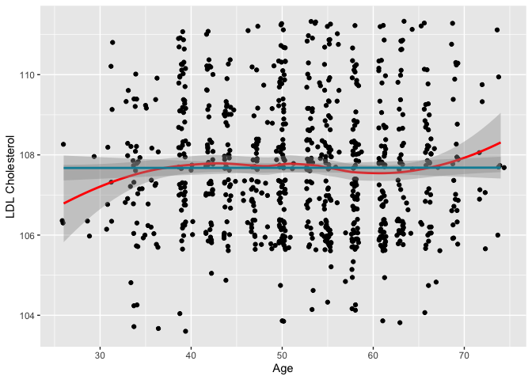

```r
scatter_plot_variables <- ggplot(data_all, aes(x = age, y = ldl1)) +
                  geom_point(position = position_jitter()) +
                  geom_smooth(colour = "red") +
                  geom_smooth(method = "lm", colour = "#088da5") +
                  labs(x = "Age", y = "LDL Cholesterol")
plot(scatter_plot_variables)
```

#### Changing the shading of the points

We can use *alpha* to change the shading of the points. This lets use quickly avoid overplotting with lots of overlapping points. We need to play with this a bit. A good place to start is 0.5 and go from there. I ended up at 0.2 which I think shows the mass of data points and avoids too much emphasis on the outlier points.

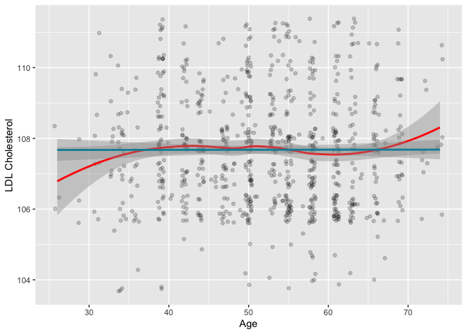

```r
scatter_plot_alpha <- ggplot(data_all, aes(x = age, y = ldl1)) +
                  geom_point(alpha = 0.2, position = position_jitter()) +
                  geom_smooth(colour = "red") +
                  geom_smooth(method = "lm", colour = "#088da5") +
                  labs(x = "Age", y = "LDL Cholesterol")
plot(scatter_plot_alpha)
```

### 4. Grouping with ggplot2

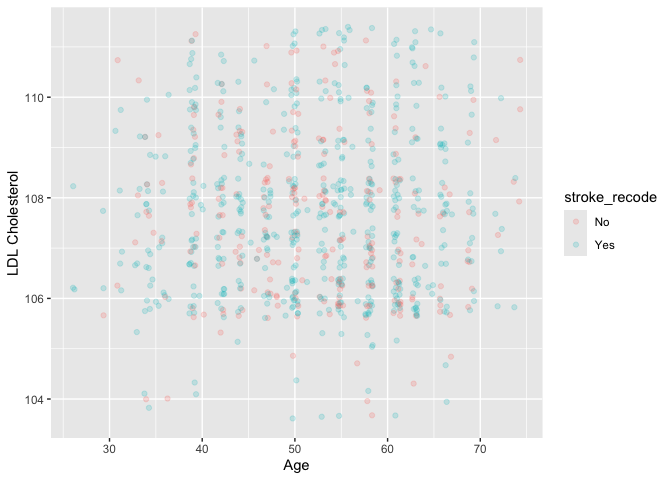

```r
scatter_plot_gender <- ggplot(data_all, aes(x = age, y = ldl1, colour = stroke_recode)) +
                  geom_point(alpha = 0.2, position = position_jitter()) +
                  labs(x = "Age", y = "LDL Cholesterol", fill = "Stroke")
plot(scatter_plot_gender)
```

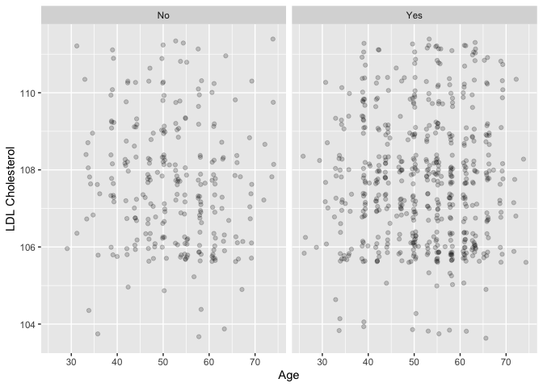

```r
scatter_plot_gender <- ggplot(data_all, aes(x = age, y = ldl1)) +
                  geom_point(alpha = 0.2, position = position_jitter()) +
                  labs(x = "Age", y = "LDL Cholesterol") +
                  facet_wrap(~ stroke_recode)
plot(scatter_plot_gender)
```

### 5. Colours and themes

Finally, there are many default colours and themes we can use to make the plots look good very quickly. A few things I use regularly.

#### Themes

**Black and White Theme**

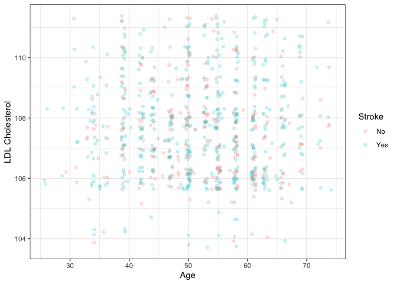

```r
scatter_plot_bw <- ggplot(data_all, aes(x = age, y = ldl1, colour = stroke_recode)) +
                  geom_point(alpha = 0.2, position = position_jitter()) +
                  labs(x = "Age", y = "LDL Cholesterol", colour = "Stroke") +
                  theme_bw()
plot(scatter_plot_bw)
```

**Classic Theme**

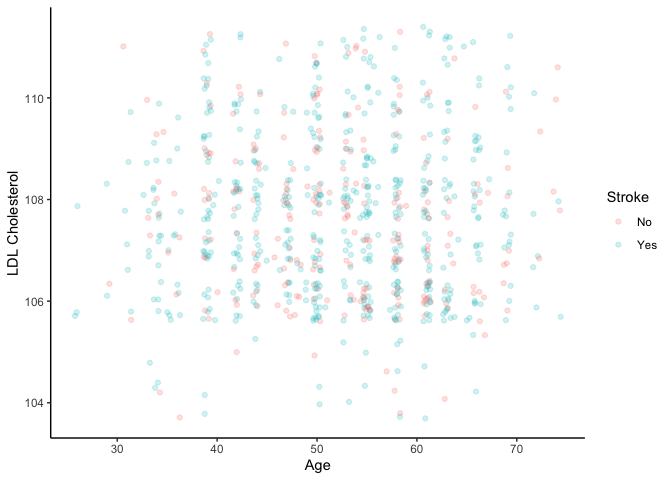

```r
scatter_plot_classic <- ggplot(data_all, aes(x = age, y = ldl1, colour = stroke_recode)) +
                  geom_point(alpha = 0.2, position = position_jitter()) +
                  labs(x = "Age", y = "LDL Cholesterol", colour = "Stroke") +
                  theme_classic()
plot(scatter_plot_classic)
```

#### Colours

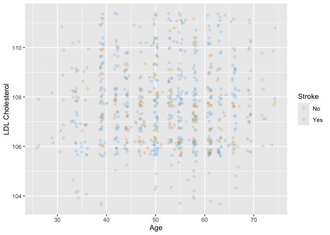

```r
scatter_plot_gender_brewer <- ggplot(data_all, aes(x = age, y = ldl1, colour = stroke_recode)) +
                  geom_point(alpha = 0.2, position = position_jitter()) +
                  scale_colour_manual(values = c("#E69F00", "#56B4E9")) +
                  labs(x = "Age", y = "LDL Cholesterol", colour = "Stroke")
plot(scatter_plot_gender_brewer)
```

### 6. Heat Maps

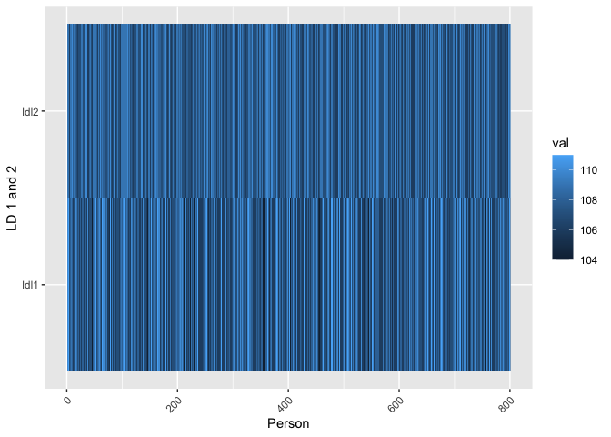

```r
data_heat <- data_all %>% select(id, ldl1, ldl2)

data_heat <- data_heat %>%
                dplyr::mutate(id = row_number()) %>%
                gather(-id, key = "key", value = "val") %>%
                mutate(isna = is.na(val))

ggplot(data = data_heat, aes(id, key, fill = val)) +
    geom_tile(alpha=1) +
    labs(x = "Person", y = "LD 1 and 2") +
    theme(axis.text.x = element_text(angle = 45, vjust = 1, hjust=1))
```

## Regression stuff

### Creating a table of bivariable associations

```r
univ_table <- data_all %>%
  select(ldl1, sex, ethgrp, age, smoking, Cancer, stroke_recode) %>%
  tbl_uvregression(
    method = glm,
    y = ldl1,
    method.args = list(family = gaussian))

univ_table %>% as_kable()
```

| **Characteristic** | **N** | **Beta** | **95% CI** | **p-value** |
| --- | --- | --- | --- | --- |
| sex | 800 | 0.14 | -0.08, 0.37 | 0.2 |
| ethgrp | 800 | 0.00 | -0.16, 0.17 | >0.9 |
| age | 800 | 0.00 | -0.01, 0.01 | >0.9 |
| smoking | 800 | 0.15 | -0.08, 0.37 | 0.2 |
| Cancer | 800 | 0.00 | -0.22, 0.23 | >0.9 |
| stroke_recode | 800 |  |  |  |
| No |  | — | — |  |
| Yes |  | 0.08 | -0.16, 0.32 | 0.5 |

### Creating a final model

```r
model_final <- glm(ldl1 ~  sex +
                           ethgrp +
                           age +
                           smoking +
                           Cancer +
                           stroke_recode,
                    data = data_all, family = "gaussian")

summary(model_final)
```

```
##
## Call:
## glm(formula = ldl1 ~ sex + ethgrp + age + smoking + Cancer +
##     stroke_recode, family = "gaussian", data = data_all)
##
## Coefficients:
##                    Estimate Std. Error t value Pr(>|t|)
## (Intercept)       1.074e+02  3.858e-01 278.527   <2e-16 ***
## sex               1.702e-01  1.183e-01   1.438    0.151
## ethgrp            1.310e-02  8.447e-02   0.155    0.877
## age              -1.601e-04  5.742e-03  -0.028    0.978
## smoking           1.514e-01  1.182e-01   1.281    0.201
## Cancer           -2.522e-02  1.159e-01  -0.218    0.828
## stroke_recodeYes  8.850e-02  1.263e-01   0.701    0.484
## ---
## Signif. codes:  0 '***' 0.001 '**' 0.01 '*' 0.05 '.' 0.1 ' ' 1
##
## (Dispersion parameter for gaussian family taken to be 2.620961)
##
##     Null deviance: 2088.8  on 799  degrees of freedom
## Residual deviance: 2078.4  on 793  degrees of freedom
## AIC: 3050.1
##
## Number of Fisher Scoring iterations: 2
```

```r
multi_table <- tbl_regression(model_final)

multi_table %>% as_kable()
```

| **Characteristic** | **Beta** | **95% CI** | **p-value** |
| --- | --- | --- | --- |
| sex | 0.17 | -0.06, 0.40 | 0.2 |
| ethgrp | 0.01 | -0.15, 0.18 | 0.9 |
| age | 0.00 | -0.01, 0.01 | >0.9 |
| smoking | 0.15 | -0.08, 0.38 | 0.2 |
| Cancer | -0.03 | -0.25, 0.20 | 0.8 |
| stroke_recode |  |  |  |
| No | — | — |  |
| Yes | 0.09 | -0.16, 0.34 | 0.5 |

### Plot a final model

We might also want to plot the results of the final model as coefficients and confidence intervals instead of showing the model in table. Can be a nice way to present the results. We are going to use the `plot_model` from the `sjPlot` package. This package leverages `ggplot2` but probably goes not offer quite as much flexibility.

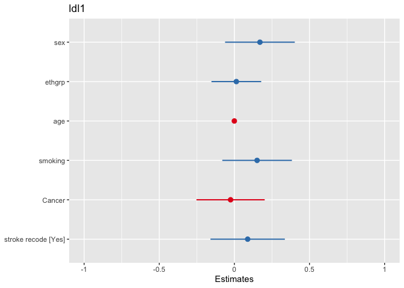

```r
plot_model(model_final, type="est")
```

## Interaction terms

We might want to check for interaction terms. There might be an interaction between smoking and cancer so let’s test that our dataset, visualize the interaction, and compare to both our bivariable models and final model.

```r
model_interaction <- glm(ldl1 ~  sex +
                           ethgrp +
                           age +
                           smoking +
                           Cancer +
                           smoking*Cancer +
                           stroke_recode,
                    data = data_all, family = "gaussian")

summary(model_interaction)
```

```
##
## Call:
## glm(formula = ldl1 ~ sex + ethgrp + age + smoking + Cancer +
##     smoking * Cancer + stroke_recode, family = "gaussian", data = data_all)
##
## Coefficients:
##                    Estimate Std. Error t value Pr(>|t|)
## (Intercept)       1.075e+02  3.875e-01 277.381   <2e-16 ***
## sex               1.769e-01  1.184e-01   1.494    0.136
## ethgrp            1.974e-02  8.459e-02   0.233    0.816
## age              -2.627e-04  5.740e-03  -0.046    0.964
## smoking          -4.356e-03  1.683e-01  -0.026    0.979
## Cancer           -1.593e-01  1.552e-01  -1.027    0.305
## stroke_recodeYes  8.252e-02  1.263e-01   0.653    0.514
## smoking:Cancer    3.037e-01  2.338e-01   1.299    0.194
## ---
## Signif. codes:  0 '***' 0.001 '**' 0.01 '*' 0.05 '.' 0.1 ' ' 1
##
## (Dispersion parameter for gaussian family taken to be 2.618692)
##
##     Null deviance: 2088.8  on 799  degrees of freedom
## Residual deviance: 2074.0  on 792  degrees of freedom
## AIC: 3050.4
##
## Number of Fisher Scoring iterations: 2
```

```r
inter_table <- tbl_regression(model_interaction)

inter_table %>% as_kable()
```

| **Characteristic** | **Beta** | **95% CI** | **p-value** |
| --- | --- | --- | --- |
| sex | 0.18 | -0.06, 0.41 | 0.14 |
| ethgrp | 0.02 | -0.15, 0.19 | 0.8 |
| age | 0.00 | -0.01, 0.01 | >0.9 |
| smoking | 0.00 | -0.33, 0.33 | >0.9 |
| Cancer | -0.16 | -0.46, 0.14 | 0.3 |
| stroke_recode |  |  |  |
| No | — | — |  |
| Yes | 0.08 | -0.17, 0.33 | 0.5 |
| smoking * Cancer | 0.30 | -0.15, 0.76 | 0.2 |

### Visualize interaction term

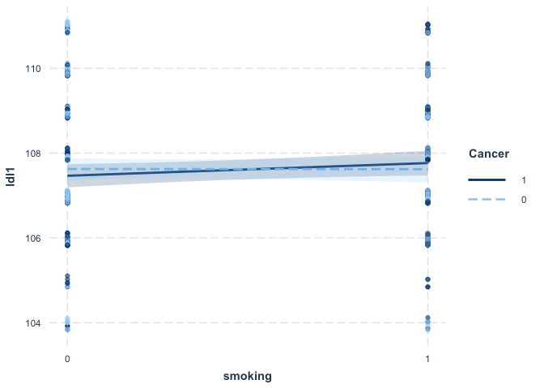

```r
plot_interaction <- interact_plot(model_interaction,
                                    pred = smoking,
                                    modx = Cancer,
                                    plot.points = TRUE,
                                    partial.residuals = TRUE,
                                    interval = TRUE,
                                    int.width = 0.95)
plot(plot_interaction)
```

## Putting it all together

We might want to make a big table with our bivariable analysis, final model, and interaction model for presentation or quickly show results. We can do that by combining tables

```r
tbl_univ_multi_inter <- tbl_merge(list(univ_table, multi_table, inter_table))

tbl_univ_multi_inter %>% as_kable()
```

| **Characteristic** | **N** | **Beta** | **95% CI** | **p-value** | **Beta** | **95% CI** | **p-value** | **Beta** | **95% CI** | **p-value** |
| --- | --- | --- | --- | --- | --- | --- | --- | --- | --- | --- |
| sex | 800 | 0.14 | -0.08, 0.37 | 0.2 | 0.17 | -0.06, 0.40 | 0.2 | 0.18 | -0.06, 0.41 | 0.14 |
| ethgrp | 800 | 0.00 | -0.16, 0.17 | >0.9 | 0.01 | -0.15, 0.18 | 0.9 | 0.02 | -0.15, 0.19 | 0.8 |
| age | 800 | 0.00 | -0.01, 0.01 | >0.9 | 0.00 | -0.01, 0.01 | >0.9 | 0.00 | -0.01, 0.01 | >0.9 |
| smoking | 800 | 0.15 | -0.08, 0.37 | 0.2 | 0.15 | -0.08, 0.38 | 0.2 | 0.00 | -0.33, 0.33 | >0.9 |
| Cancer | 800 | 0.00 | -0.22, 0.23 | >0.9 | -0.03 | -0.25, 0.20 | 0.8 | -0.16 | -0.46, 0.14 | 0.3 |
| stroke_recode | 800 |  |  |  |  |  |  |  |  |  |
| No |  | — | — |  | — | — |  | — | — |  |
| Yes |  | 0.08 | -0.16, 0.32 | 0.5 | 0.09 | -0.16, 0.34 | 0.5 | 0.08 | -0.17, 0.33 | 0.5 |
| smoking * Cancer |  |  |  |  |  |  |  | 0.30 | -0.15, 0.76 | 0.2 |

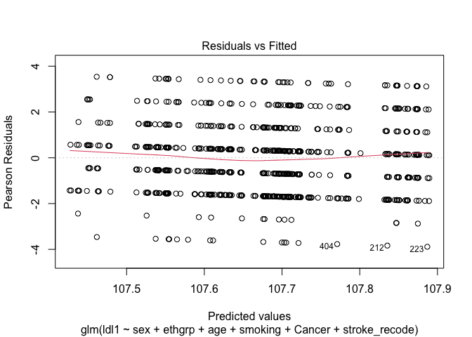

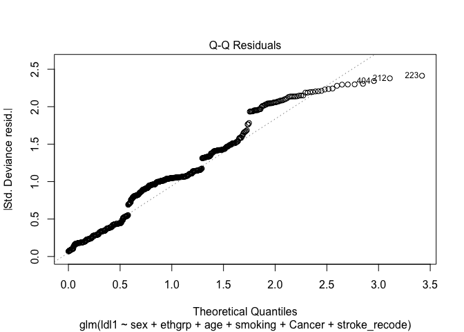

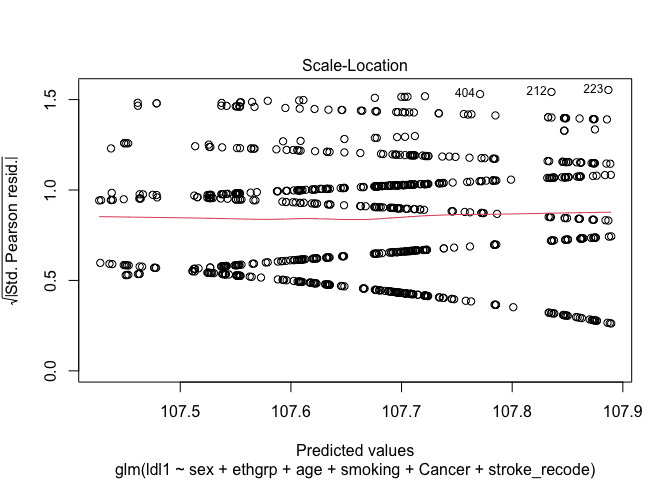

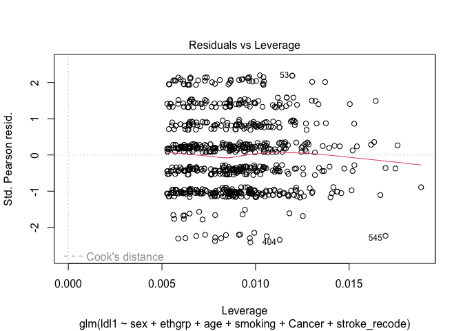

```r
plot(model_final)
```

## Multilevel Models

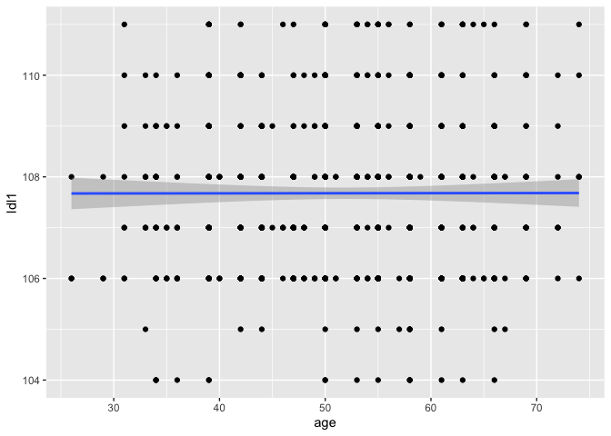

```r
ldl1_age <- ggplot(data_all, aes(x = age, y = ldl1)) +
                    geom_point() +
                    geom_smooth(method='lm', formula= y~x)
plot(ldl1_age)
```

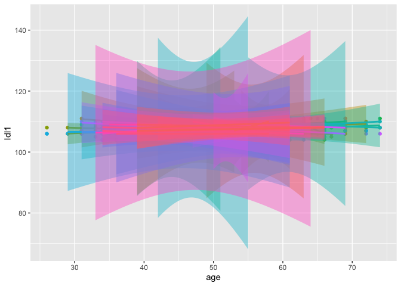

```r
age_ldl1_parent <- ggplot(data_all, aes(x = age, y = ldl1, colour = parent, fill = parent)) +
                    geom_point() +
                    geom_smooth(method='lm', formula= y~x) +
                    theme(legend.position="none")
plot(age_ldl1_parent)
```

## Modelling intercepts

Linear regression. Assumes only one intercept for the entire sample.

```r
lm_1 <- lm(ldl1 ~ 1, data = data_all)
```

Multil-level model. Assumes one intercept for each group. In our case parents, it could be people, neighbourhoods, etc.

```r
lme_1 <- lme(ldl1 ~ 1, random = ~ 1 | parent, data = data_all)
summary(lme_1)
```

```
## Linear mixed-effects model fit by REML
##   Data: data_all
##        AIC      BIC    logLik
##   3047.973 3062.023 -1520.986
##
## Random effects:
##  Formula: ~1 | parent
##          (Intercept) Residual
## StdDev: 0.0001064242 1.616868
##
## Fixed effects:  ldl1 ~ 1
##                Value  Std.Error  DF  t-value p-value
## (Intercept) 107.6775 0.05716491 634 1883.629       0
##
## Standardized Within-Group Residuals:
##        Min         Q1        Med         Q3        Max
## -2.2744593 -1.0374998  0.1994597  0.8179395  2.0548990
##
## Number of Observations: 800
## Number of Groups: 634
```

```r
lme_1 <- lme(ldl1 ~ 1, random = ~ 1 | parent, data = data_all)
```

## Adding level 1 covariates

```r
lme_2 <- lme(ldl1 ~ age + stroke_recode + smoking, random = ~ 1 | parent, data = data_all)
summary(lme_2)
```

```
## Linear mixed-effects model fit by REML
##   Data: data_all
##       AIC      BIC    logLik
##   3065.43 3093.508 -1526.715
##
## Random effects:
##  Formula: ~1 | parent
##          (Intercept) Residual
## StdDev: 0.0001815086 1.618026
##
## Fixed effects:  ldl1 ~ age + stroke_recode + smoking
##                      Value  Std.Error  DF  t-value p-value
## (Intercept)      107.58440 0.31432491 633 342.2713  0.0000
## age               -0.00014 0.00570733 163  -0.0253  0.9799
## stroke_recodeYes   0.05677 0.12419441 163   0.4571  0.6482
## smoking            0.13992 0.11666565 163   1.1993  0.2321
##  Correlation:
##                  (Intr) age    strk_Y
## age              -0.939
## stroke_recodeYes -0.262  0.019
## smoking          -0.073 -0.053 -0.151
##
## Standardized Within-Group Residuals:
##        Min         Q1        Med         Q3        Max
## -2.3333740 -0.9749368  0.1392195  0.7585044  2.1166741
##
## Number of Observations: 800
## Number of Groups: 634
```

## Plotting fitted versus actual values

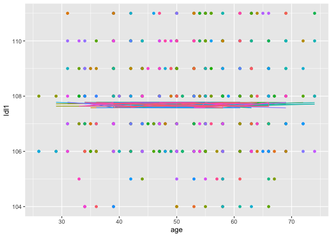

```r
data_all$fitted_lm <- predict(lme_2)

fitted_plot <- ggplot(data_all, aes(x = age, y = ldl1, colour = parent)) +
                        geom_point() +
                        geom_line(aes(y = fitted_lm, colour = parent)) +
                        theme(legend.position="none")
plot(fitted_plot)
```

### Code for creating synthetic datasets

Not run

```
where <- make.where(data, "all")

method <- make.method(data, where = where)
method[method == "pmm"] <- "norm"

syn_param <- mice(data,
                  m = 10,
                  maxit = 1,
                  method = "cart",
                  where = where,
                  printFlag = FALSE)

data2 <- complete(syn_param, 1)
data3 <- complete(syn_param, 2)
data4 <- complete(syn_param, 3)

write.csv(data2, "data2.csv")
write.csv(data3, "data3.csv")
write.csv(data4, "data4.csv")
```

### Generating random names

```
names_data <- NULL

names_data$id <- seq(from = 1, to = 800)

names_data$parent <- randomNames(800,
                      which.names="first",
                      sample.with.replacement=TRUE,
                      return.complete.data=FALSE)

names_data <- as.data.frame(names_data)

write.csv(names_data, "names.csv")
```